# Exercises

Andy Pham

April 21, 2016

## Exercise 1

```r
sum(2000:20000)
```

```
## [1] 198011000
```

The sum is: 198011000

## Exercise 2

In the code snippet, a is assigned the value 5, b is assigned the vector from that holds the numbers 2 to 20 incremented by 1. a and b are then printed out.

## Exercise 3

```r
a <- 5
b <- 2:20
sum(a, b)
```

```
## [1] 214
```

```r
a + b
```

```
##  [1]  7  8  9 10 11 12 13 14 15 16 17 18 19 20 21 22 23 24 25
```

I get different results because sum adds all the numbers stored in both a and b while the “+” adds a to every element in b because b is a vector.

## Exercise 4

```r
sum(b[5:10])
```

```
## [1] 51
```

The sum is 51.

## Exercise 5

```r
sum(b[c(3, 8, 10)])
```

```
## [1] 24
```

The sum is 24.

## Exercise 6

```r
m <- matrix(data=1:25, ncol=5, byrow=T)
m
```

```
##      [,1] [,2] [,3] [,4] [,5]
## [1,]    1    2    3    4    5
## [2,]    6    7    8    9   10
## [3,]   11   12   13   14   15
## [4,]   16   17   18   19   20
## [5,]   21   22   23   24   25
```

```r
c(m[, 3], m[, 4], m[, 5])
```

```
##  [1]  3  8 13 18 23  4  9 14 19 24  5 10 15 20 25
```

When extracting from a 2D object, the first number represents the row and the second number represents the column. m[3,] will return all the values in row 3. You extract the columns of m together using c(m[, 3], m[, 4], m[, 5]).

## Exercise 7

```r
cbind(m, 101:105)
```

```
##      [,1] [,2] [,3] [,4] [,5] [,6]
## [1,]    1    2    3    4    5  101
## [2,]    6    7    8    9   10  102
## [3,]   11   12   13   14   15  103
## [4,]   16   17   18   19   20  104
## [5,]   21   22   23   24   25  105
```

```r
n <- 1:5
rbind(n, m)
```

```
##   [,1] [,2] [,3] [,4] [,5]
## n    1    2    3    4    5
##      1    2    3    4    5
##      6    7    8    9   10
##     11   12   13   14   15
##     16   17   18   19   20
##     21   22   23   24   25
```

The cbind command adds a column to the matrix specified with the data specified. In this case, cbind added a column to m with the numbers 101 to 105. Rbind would add another row to the matrix.

```r
fly.worm <- read.delim("../Data/fly2worm.blastp.gz", header=F)
#change the file name and path to match whatever you used.
#the header=F argument tells R that the first row contains data, not column names
#takes a while to read in this large data set.
head(fly.worm)
```

```
##         V1          V2    V3  V4  V5 V6 V7  V8 V9 V10   V11 V12
## 1 2RSSE.1a FBpp0304402 48.35 242 122  2 19 258 31 271 9e-77 242
## 2 2RSSE.1a FBpp0304403 48.35 242 122  2 19 258 31 271 2e-75 243
## 3 2RSSE.1a FBpp0292544 48.35 242 122  2 19 258 31 271 3e-74 243
## 4 2RSSE.1a FBpp0075321 48.35 242 122  2 19 258 31 271 5e-74 243
## 5 2RSSE.1a FBpp0075320 48.35 242 122  2 19 258 31 271 5e-74 243
## 6 2RSSE.1a FBpp0075322 48.35 242 122  2 19 258 31 271 3e-72 243
```

```r
summary(fly.worm)
```

```
##         V1                   V2               V3              V4
##  F15G9.4d:  3909   FBpp0304926:  1080   Min.   :17.97   Min.   :  32.0
##  F15G9.4a:  3745   FBpp0304924:  1078   1st Qu.:26.17   1st Qu.: 203.0
##  C09D1.1b:  3715   FBpp0304923:  1074   Median :29.56   Median : 268.0
##  F15G9.4b:  3687   FBpp0304921:  1072   Mean   :31.83   Mean   : 343.1
##  C09D1.1g:  3617   FBpp0304925:  1070   3rd Qu.:34.62   3rd Qu.: 387.0
##  C09D1.1f:  3545   FBpp0304929:  1069   Max.   :99.33   Max.   :5795.0
##  (Other) :481883   (Other)    :497658
##        V5               V6                V7                V8
##  Min.   :   1.0   Min.   :  0.000   Min.   :    1.0   Min.   :   33
##  1st Qu.: 121.0   1st Qu.:  4.000   1st Qu.:   38.0   1st Qu.:  285
##  Median : 162.0   Median :  7.000   Median :  129.0   Median :  433
##  Mean   : 203.7   Mean   :  9.836   Mean   :  716.2   Mean   : 1039
##  3rd Qu.: 227.0   3rd Qu.: 11.000   3rd Qu.:  444.0   3rd Qu.:  789
##  Max.   :3161.0   Max.   :172.000   Max.   :18345.0   Max.   :18531
##
##        V9               V10               V11                 V12
##  Min.   :    1.0   Min.   :   33.0   Min.   :0.000e+00   Min.   :  55.5
##  1st Qu.:   48.0   1st Qu.:  322.0   1st Qu.:0.000e+00   1st Qu.:  79.0
##  Median :  208.0   Median :  515.0   Median :0.000e+00   Median :  98.2
##  Mean   :  647.7   Mean   :  971.7   Mean   :2.205e-12   Mean   : 135.1
##  3rd Qu.:  544.0   3rd Qu.:  909.0   3rd Qu.:4.000e-15   3rd Qu.: 139.0
##  Max.   :22596.0   Max.   :22891.0   Max.   :1.000e-10   Max.   :5266.0
##
```

```r
colnames(fly.worm) <- c("qid", "sid", "pct", "len", "mis", "gaps", "qb", "qe", "sb", "se", "E", "S")
head(fly.worm)
```

```
##        qid         sid   pct len mis gaps qb  qe sb  se     E   S
## 1 2RSSE.1a FBpp0304402 48.35 242 122    2 19 258 31 271 9e-77 242
## 2 2RSSE.1a FBpp0304403 48.35 242 122    2 19 258 31 271 2e-75 243
## 3 2RSSE.1a FBpp0292544 48.35 242 122    2 19 258 31 271 3e-74 243
## 4 2RSSE.1a FBpp0075321 48.35 242 122    2 19 258 31 271 5e-74 243
## 5 2RSSE.1a FBpp0075320 48.35 242 122    2 19 258 31 271 5e-74 243
## 6 2RSSE.1a FBpp0075322 48.35 242 122    2 19 258 31 271 3e-72 243
```

```r
summary(fly.worm)
```

```
##        qid                  sid              pct             len
##  F15G9.4d:  3909   FBpp0304926:  1080   Min.   :17.97   Min.   :  32.0
##  F15G9.4a:  3745   FBpp0304924:  1078   1st Qu.:26.17   1st Qu.: 203.0
##  C09D1.1b:  3715   FBpp0304923:  1074   Median :29.56   Median : 268.0
##  F15G9.4b:  3687   FBpp0304921:  1072   Mean   :31.83   Mean   : 343.1
##  C09D1.1g:  3617   FBpp0304925:  1070   3rd Qu.:34.62   3rd Qu.: 387.0
##  C09D1.1f:  3545   FBpp0304929:  1069   Max.   :99.33   Max.   :5795.0
##  (Other) :481883   (Other)    :497658
##       mis              gaps               qb                qe
##  Min.   :   1.0   Min.   :  0.000   Min.   :    1.0   Min.   :   33
##  1st Qu.: 121.0   1st Qu.:  4.000   1st Qu.:   38.0   1st Qu.:  285
##  Median : 162.0   Median :  7.000   Median :  129.0   Median :  433
##  Mean   : 203.7   Mean   :  9.836   Mean   :  716.2   Mean   : 1039
##  3rd Qu.: 227.0   3rd Qu.: 11.000   3rd Qu.:  444.0   3rd Qu.:  789
##  Max.   :3161.0   Max.   :172.000   Max.   :18345.0   Max.   :18531
##
##        sb                se                E                   S
##  Min.   :    1.0   Min.   :   33.0   Min.   :0.000e+00   Min.   :  55.5
##  1st Qu.:   48.0   1st Qu.:  322.0   1st Qu.:0.000e+00   1st Qu.:  79.0
##  Median :  208.0   Median :  515.0   Median :0.000e+00   Median :  98.2
##  Mean   :  647.7   Mean   :  971.7   Mean   :2.205e-12   Mean   : 135.1
##  3rd Qu.:  544.0   3rd Qu.:  909.0   3rd Qu.:4.000e-15   3rd Qu.: 139.0
##  Max.   :22596.0   Max.   :22891.0   Max.   :1.000e-10   Max.   :5266.0
##
```

## Exercise 8

```r
evalue <- sum(fly.worm["E"] == 0)
pID <- sum(fly.worm["pct"] > 50)
evalue_percent <- sum(fly.worm["E"] == 0)/nrow(fly.worm)
percentID <- sum(fly.worm["pct"] > 50)/nrow(fly.worm)
evalue_pID <- sum(fly.worm["E"] == 0 & fly.worm["pct"] < 50)
minpID <- subset(fly.worm, E == 0)
min(minpID["pct"])
```

```
## [1] 24.07
```

**E-value of 0**: 7531 hits, 0.01494 **Percent Identity > 50**: 20928 hits, 0.04151 **E-value of 0 and Percent Identity < 50**: 3351 hits **Minimum Percent Identity of Hits with E-value of 0**: 24.07

## Exercise 9

I am surprised that low percent identity sequences can still have an E-value of 0. The alignment property that affects the E-value being 0 even when the percent identity is less than 50 is raw score. The higher the raw score, the lower the e-value. Thus, when the raw score is high enough, the e-value is small enough to get rounded to 0.

```r
mp <- cbind(fly.worm["E"], fly.worm["S"])
summary(mp)
```

```
##        E                   S
##  Min.   :0.000e+00   Min.   :  55.5
##  1st Qu.:0.000e+00   1st Qu.:  79.0
##  Median :0.000e+00   Median :  98.2
##  Mean   :2.205e-12   Mean   : 135.1
##  3rd Qu.:4.000e-15   3rd Qu.: 139.0
##  Max.   :1.000e-10   Max.   :5266.0
```

```r
mp_small <- subset(mp, E == 0)
mp_big <- subset(mp, E > 0)
mp_middle <- subset(mp, E < 2e-12)
mp_middle2 <- subset(mp, E < 2e-14)
summary(mp_small)
```

```
##        E           S
##  Min.   :0   Min.   : 511
##  1st Qu.:0   1st Qu.: 627
##  Median :0   Median : 766
##  Mean   :0   Mean   : 961
##  3rd Qu.:0   3rd Qu.:1078
##  Max.   :0   Max.   :5266
```

```r
summary(mp_big)
```

```
##        E                   S
##  Min.   :0.000e+00   Min.   : 55.5
##  1st Qu.:0.000e+00   1st Qu.: 79.0
##  Median :0.000e+00   Median : 97.4
##  Mean   :2.238e-12   Mean   :122.5
##  3rd Qu.:5.000e-15   3rd Qu.:137.0
##  Max.   :1.000e-10   Max.   :632.0
```

```r
summary(mp_middle)
```

```
##        E                   S
##  Min.   :0.000e+00   Min.   :  60.5
##  1st Qu.:0.000e+00   1st Qu.:  84.3
##  Median :0.000e+00   Median : 103.0
##  Mean   :4.081e-14   Mean   : 142.8
##  3rd Qu.:1.000e-16   3rd Qu.: 147.0
##  Max.   :1.000e-12   Max.   :5266.0
```

```r
summary(mp_middle2)
```

```
##        E                   S
##  Min.   :0.000e+00   Min.   :  64.3
##  1st Qu.:0.000e+00   1st Qu.:  90.9
##  Median :0.000e+00   Median : 112.0
##  Mean   :4.136e-16   Mean   : 153.1
##  3rd Qu.:1.000e-18   3rd Qu.: 156.0
##  Max.   :1.000e-14   Max.   :5266.0
```

As the summaries show, the lower the E-values become, the higher the mean of the raw score “S” becomes. When E is 0 as shown in mp_small, the mean of the raw scores is many times higher than that if E is greater than 0 as seen in mp_big. Then as the high bounds for E decreeases, the mean of the raw score increases as seen in mp_middle and mp_middle2.

## Exercise 10

```r
fly.worm.small <- sample(nrow(fly.worm), 10000)
summary(fly.worm[fly.worm.small, ])
```

```
##        qid                sid            pct             len
##  F15G9.4d:  94   FBpp0311242:  28   Min.   :18.63   Min.   :  39
##  F15G9.4b:  79   FBpp0304921:  27   1st Qu.:26.24   1st Qu.: 202
##  C09D1.1g:  78   FBpp0304928:  27   Median :29.68   Median : 267
##  C09D1.1f:  77   FBpp0304920:  24   Mean   :31.81   Mean   : 339
##  F15G9.4a:  73   FBpp0306552:  24   3rd Qu.:34.58   3rd Qu.: 381
##  C09D1.1a:  61   FBpp0304923:  23   Max.   :98.06   Max.   :4506
##  (Other) :9538   (Other)    :9847
##       mis              gaps               qb                qe
##  Min.   :   2.0   Min.   :  0.000   Min.   :    1.0   Min.   :   44
##  1st Qu.: 120.0   1st Qu.:  4.000   1st Qu.:   37.0   1st Qu.:  284
##  Median : 161.0   Median :  7.000   Median :  126.0   Median :  431
##  Mean   : 201.5   Mean   :  9.679   Mean   :  700.5   Mean   : 1020
##  3rd Qu.: 224.0   3rd Qu.: 11.000   3rd Qu.:  438.5   3rd Qu.:  783
##  Max.   :2678.0   Max.   :148.000   Max.   :18244.0   Max.   :18518
##
##        sb                se              E                   S
##  Min.   :    1.0   Min.   :   54   Min.   :0.000e+00   Min.   :  56.2
##  1st Qu.:   47.0   1st Qu.:  321   1st Qu.:0.000e+00   1st Qu.:  79.0
##  Median :  205.0   Median :  512   Median :0.000e+00   Median :  97.8
##  Mean   :  649.8   Mean   :  970   Mean   :2.247e-12   Mean   : 133.4
##  3rd Qu.:  540.2   3rd Qu.:  908   3rd Qu.:5.000e-15   3rd Qu.: 140.0
##  Max.   :22124.0   Max.   :22891   Max.   :1.000e-10   Max.   :3114.0
##
```

## Exercise 11

```r
stereotype_db <- read.delim("stereotypes.csv", sep =",")
summary(stereotype_db)
```

```
##      population     gender        coffee         computer
##  hippie   :200   female:400   Min.   : 0.00   Min.   : 0.00
##  hipster  :199   male  :399   1st Qu.: 6.00   1st Qu.:12.00
##  metalhead:200                Median :12.00   Median :24.00
##  nerd     :200                Mean   :13.84   Mean   :28.65
##                               3rd Qu.:22.00   3rd Qu.:43.00
##                               Max.   :36.00   Max.   :95.00
##      shower            beer           tacos            age
##  Min.   : 0.000   Min.   : 0.00   Min.   : 0.00   Min.   :17.00
##  1st Qu.: 4.000   1st Qu.: 6.00   1st Qu.:11.00   1st Qu.:20.00
##  Median : 7.000   Median :17.00   Median :14.00   Median :22.00
##  Mean   : 6.607   Mean   :21.13   Mean   :14.03   Mean   :22.34
##  3rd Qu.: 9.000   3rd Qu.:33.00   3rd Qu.:17.00   3rd Qu.:24.00
##  Max.   :18.000   Max.   :80.00   Max.   :42.00   Max.   :27.00
```

```r
head(stereotype_db)
```

```
##   population gender coffee computer shower beer tacos age
## 1     hippie female      1        1      8    0     8  17
## 2       nerd female      2       13      7    0     4  17
## 3       nerd female      6       40      8    0     5  17
## 4       nerd female      3       41     10    0     6  17
## 5       nerd female     15       42      9    0    11  17
## 6       nerd female      6       42      9    0     6  17
```

## Activity Break for Intro to Plotting

### AB1-1

```r
nerds_and_metal <- subset(stereotype_db, population == "nerd" | population == "metalhead")
summary(nerds_and_metal)
```

```
##      population     gender        coffee         computer
##  hippie   :  0   female:200   Min.   : 0.00   Min.   : 1.00
##  hipster  :  0   male  :200   1st Qu.: 5.00   1st Qu.:16.00
##  metalhead:200                Median :11.00   Median :24.50
##  nerd     :200                Mean   :11.23   Mean   :33.24
##                               3rd Qu.:17.00   3rd Qu.:51.00
##                               Max.   :30.00   Max.   :95.00
##      shower           beer           tacos            age
##  Min.   : 0.00   Min.   : 0.00   Min.   : 0.00   Min.   :17.00
##  1st Qu.: 4.00   1st Qu.: 4.00   1st Qu.: 8.00   1st Qu.:20.00
##  Median : 8.00   Median : 7.50   Median :14.00   Median :22.00
##  Mean   : 7.28   Mean   :20.23   Mean   :14.49   Mean   :22.37
##  3rd Qu.:10.00   3rd Qu.:37.00   3rd Qu.:19.00   3rd Qu.:24.00
##  Max.   :18.00   Max.   :80.00   Max.   :42.00   Max.   :27.00
```

### AB1-2

```r
males.only <- subset(stereotype_db, gender == "male" & beer > 25 & tacos > 20)
summary(males.only)
```

```
##      population    gender       coffee         computer
##  hippie   : 0   female: 0   Min.   : 6.00   Min.   :11.00
##  hipster  : 4   male  :72   1st Qu.:16.75   1st Qu.:16.00
##  metalhead:68               Median :19.00   Median :18.00
##  nerd     : 0               Mean   :19.29   Mean   :19.19
##                             3rd Qu.:22.00   3rd Qu.:21.00
##                             Max.   :31.00   Max.   :48.00
##      shower            beer           tacos            age
##  Min.   : 0.000   Min.   :26.00   Min.   :21.00   Min.   :19.00
##  1st Qu.: 2.000   1st Qu.:36.00   1st Qu.:23.00   1st Qu.:21.00
##  Median : 4.000   Median :43.00   Median :25.00   Median :22.00
##  Mean   : 4.722   Mean   :45.47   Mean   :26.15   Mean   :21.81
##  3rd Qu.: 6.000   3rd Qu.:56.00   3rd Qu.:28.00   3rd Qu.:23.00
##  Max.   :16.000   Max.   :80.00   Max.   :42.00   Max.   :25.00
```

There are more males in the metalhead category who binge drink and eat over 20 tacos a week.

### AB1-3

```r
print("How many females total spend more than 2 hours on the computer and drink more than 12 cups of coffee in a week?")
```

```
## [1] "How many females total spend more than 2 hours on the computer and drink more than 12 cups of coffee in a week?"
```

```r
females.ask <- subset(stereotype_db, gender == "female" & computer > 2 & coffee > 12)
summary(females.ask)
```

```
##      population    gender        coffee         computer
##  hippie   : 2   female:161   Min.   :13.00   Min.   : 3.00
##  hipster  :99   male  :  0   1st Qu.:17.00   1st Qu.:16.00
##  metalhead:55                Median :23.00   Median :37.00
##  nerd     : 5                Mean   :22.08   Mean   :30.76
##                              3rd Qu.:26.00   3rd Qu.:41.00
##                              Max.   :36.00   Max.   :74.00
##      shower            beer           tacos           age
##  Min.   : 0.000   Min.   : 0.00   Min.   : 1.0   Min.   :17.00
##  1st Qu.: 5.000   1st Qu.:17.00   1st Qu.:13.0   1st Qu.:20.00
##  Median : 8.000   Median :28.00   Median :15.0   Median :22.00
##  Mean   : 7.391   Mean   :28.58   Mean   :14.8   Mean   :22.22
##  3rd Qu.:10.000   3rd Qu.:39.00   3rd Qu.:17.0   3rd Qu.:23.00
##  Max.   :18.000   Max.   :73.00   Max.   :20.0   Max.   :27.00
```

161 females total.

### AB_4:

In R, “==” means if left hand side is equal to right side, then return true, else return false.

## Visualization with ggplot2 (Plotting tutorial)

### AB2-1

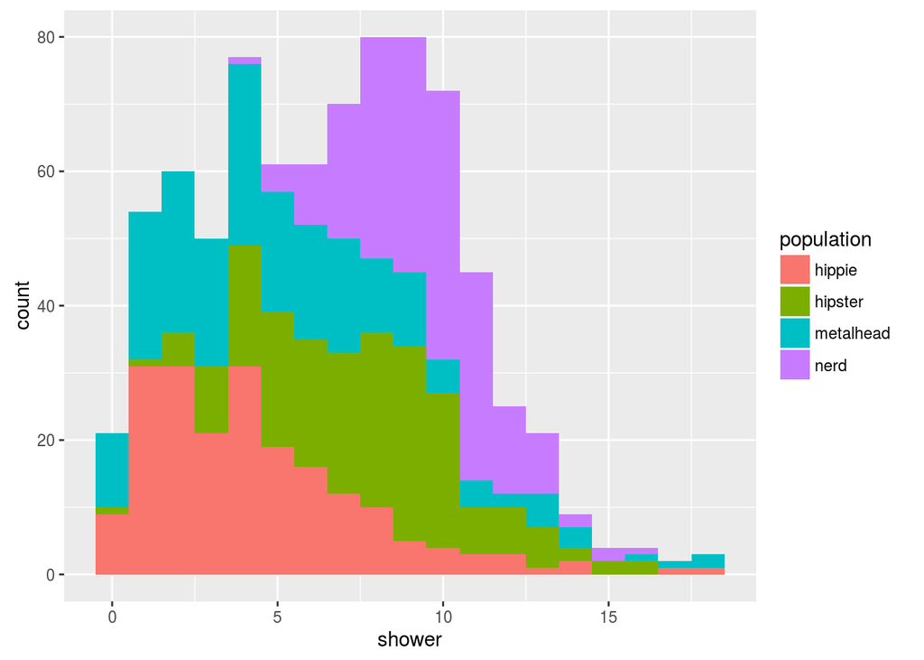

```r
qplot(shower, data=stereotype_db, geom="histogram", fill=population, binwidth= 1)
```

### AB2-2

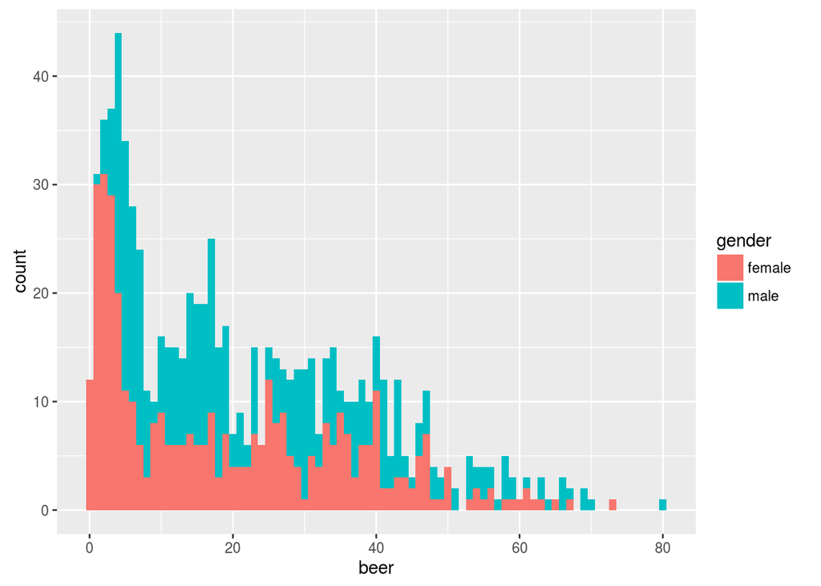

```r
qplot(beer, data=stereotype_db, geom="histogram", fill=gender, binwidth= 1)
```

### AB2-3

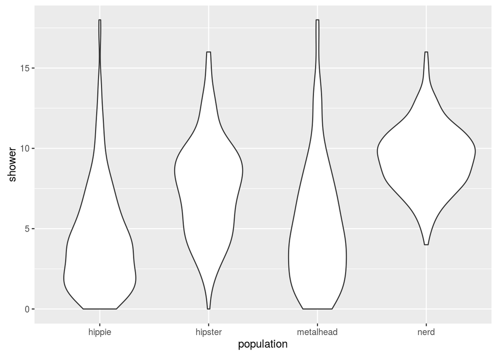

```r
ggplot(stereotype_db, aes(population, shower)) + geom_violin()
```

## Combining Subset with Visualization (Plotting tutorial)

### AB3-1

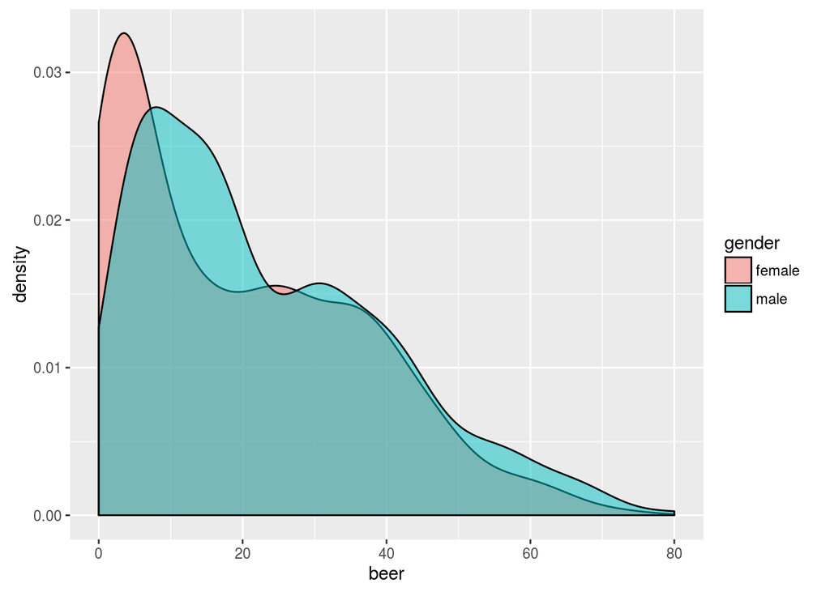

```r
nerds_only <- subset(stereotype_db, population == "nerd")
qplot(beer, data=stereotype_db, geom ="density", fill=gender, alpha=I(0.5))
```

### AB3-2

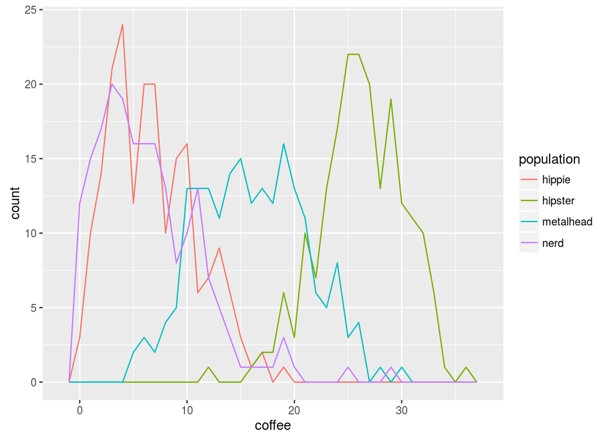

```r
qplot(coffee, data=stereotype_db, geom="freqpoly", colour = population, binwidth = 1)
```

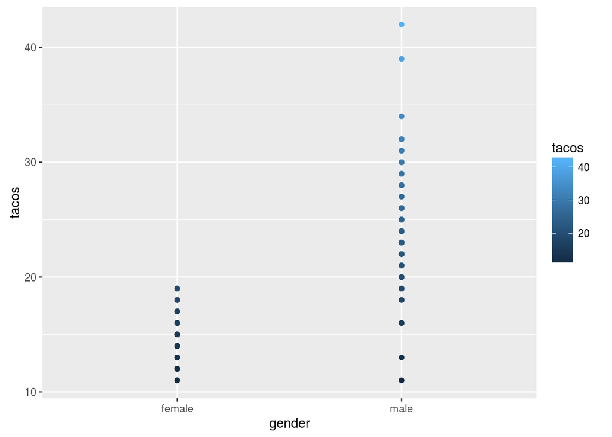

```r
metal <- subset(stereotype_db, population == "metalhead")
qplot(gender, tacos, data=metal, geom = "point", colour=tacos)
```

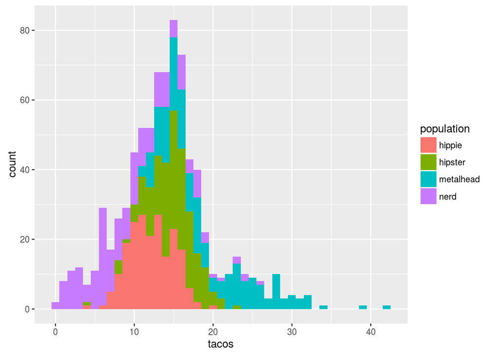

```r
qplot(tacos,  data=stereotype_db, geom = "histogram", fill=population, binwidth=1)
```

### AB3-3

```r
summary(stereotype_db)
```

```
##      population     gender        coffee         computer
##  hippie   :200   female:400   Min.   : 0.00   Min.   : 0.00
##  hipster  :199   male  :399   1st Qu.: 6.00   1st Qu.:12.00
##  metalhead:200                Median :12.00   Median :24.00
##  nerd     :200                Mean   :13.84   Mean   :28.65
##                               3rd Qu.:22.00   3rd Qu.:43.00
##                               Max.   :36.00   Max.   :95.00
##      shower            beer           tacos            age
##  Min.   : 0.000   Min.   : 0.00   Min.   : 0.00   Min.   :17.00
##  1st Qu.: 4.000   1st Qu.: 6.00   1st Qu.:11.00   1st Qu.:20.00
##  Median : 7.000   Median :17.00   Median :14.00   Median :22.00
##  Mean   : 6.607   Mean   :21.13   Mean   :14.03   Mean   :22.34
##  3rd Qu.: 9.000   3rd Qu.:33.00   3rd Qu.:17.00   3rd Qu.:24.00
##  Max.   :18.000   Max.   :80.00   Max.   :42.00   Max.   :27.00
```

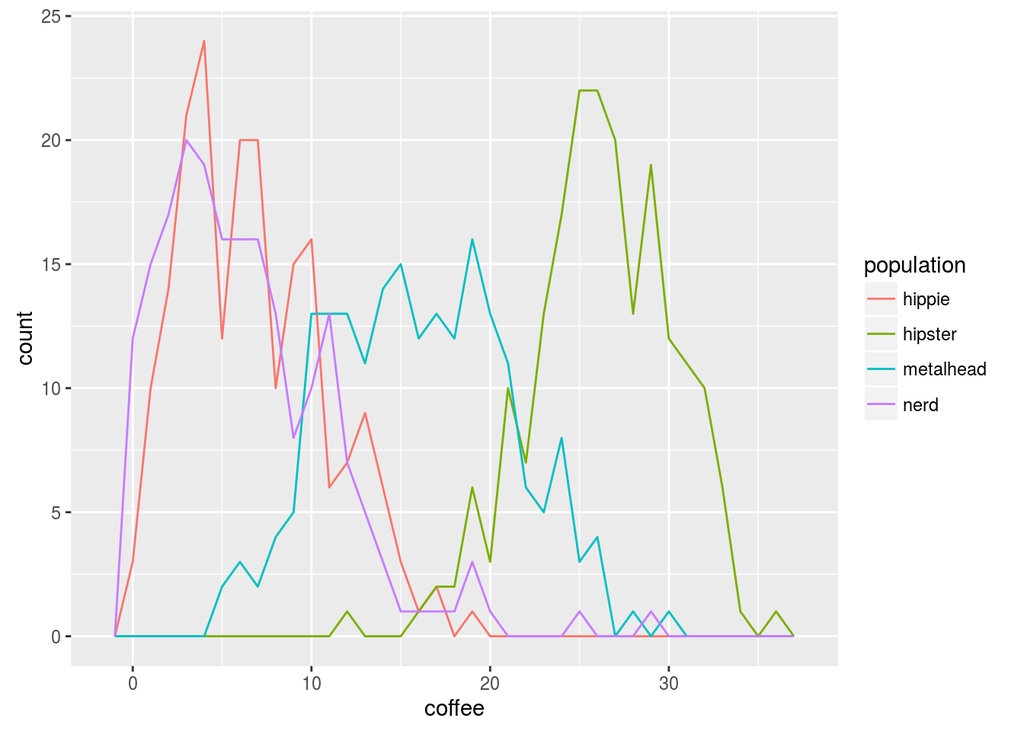

```r
qplot(coffee, data=stereotype_db, geom ="freqpoly", colour=population, binwidth=1)
```

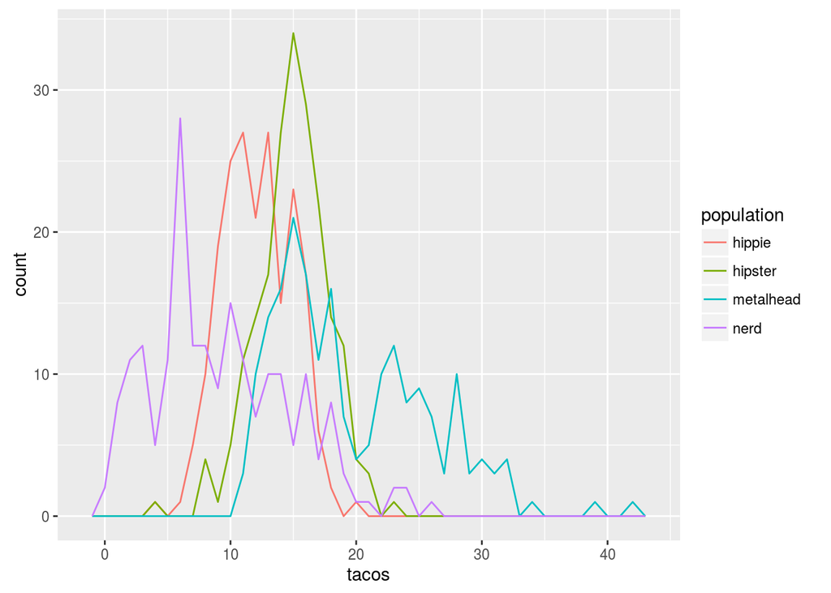

```r
qplot(tacos, data=stereotype_db, geom ="freqpoly", colour=population, binwidth=1)
```

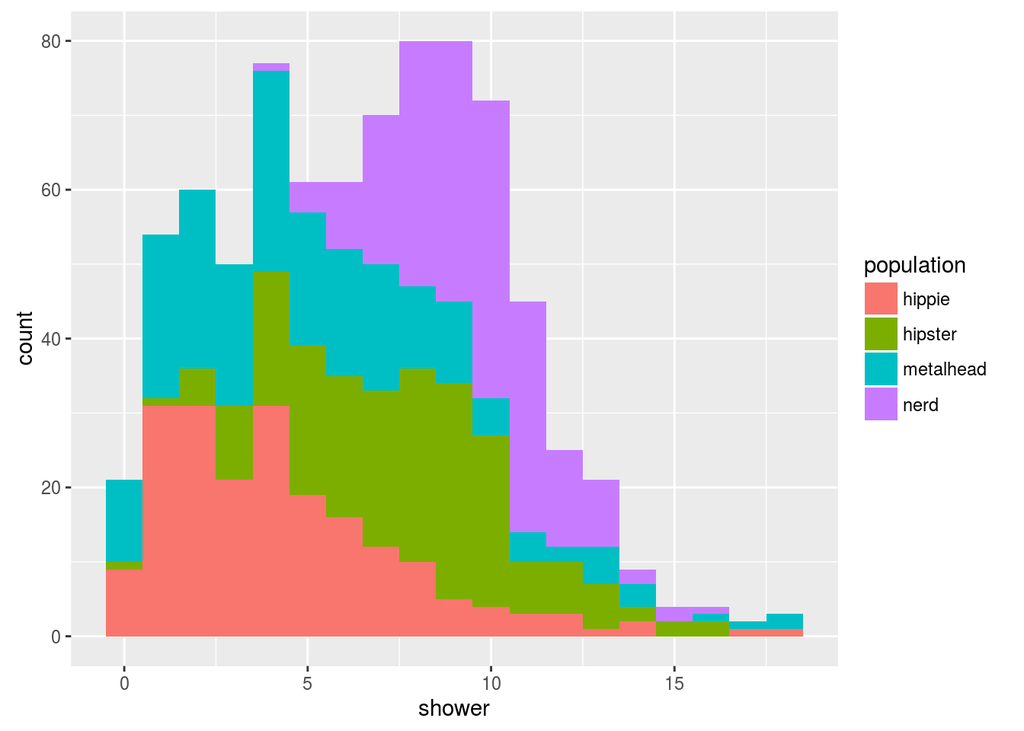

```r
qplot(shower, data=stereotype_db, geom="histogram", fill=population, binwidth=1)
```

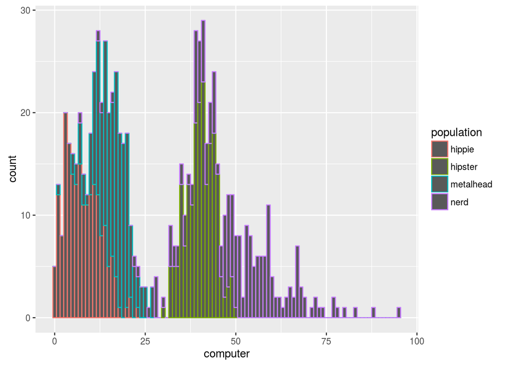

```r
qplot(computer, data=stereotype_db, geom="histogram", colour = population, binwidth=1)
```

Three hypotheses: 1. The more a person showers and goes on the computer, the more likely it is that they will be a nerd. 2. As the cups of coffee increase, the number of hipsters increase. 3. As the number of tacos increase, the amount of nerds, hippies, and hipsters decrease.

## Visualization with the ggplot function (Plotting tutorial)

### AB4-1

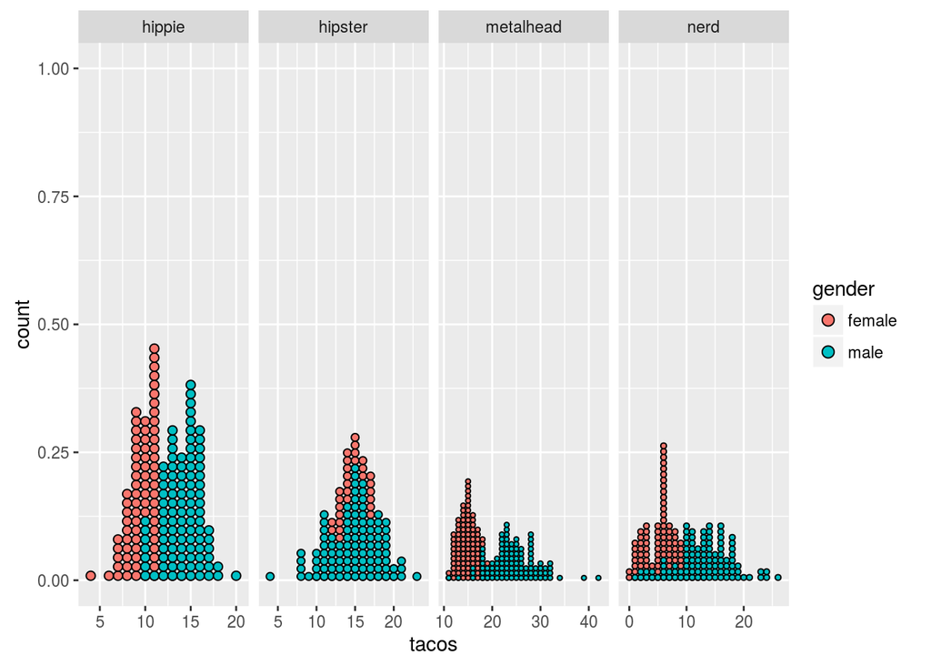

```r
p <- ggplot(stereotype_db, aes(tacos, fill=gender))
p + geom_dotplot(binwidth=1) + facet_grid(~population, scales="free")
```

### AB4-2

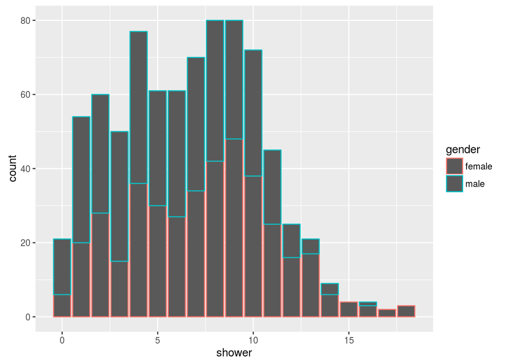

```r
a <- ggplot(stereotype_db, aes(shower, colour=gender))
b <- ggplot(stereotype_db, aes(shower, fill=gender))
a + geom_bar()
```

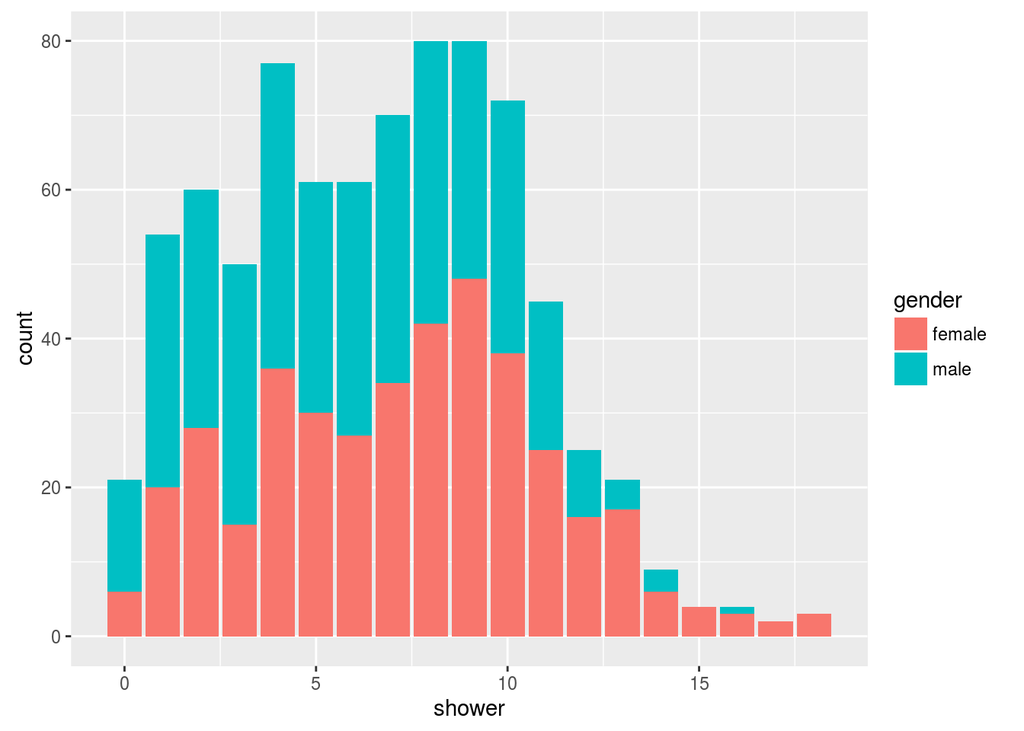

```r
b + geom_bar()
```

color= means to outline the edge of the unique attributes with different colors while fill= means to fill the whole bar or symbol with color, edges and all.

### AB5-1

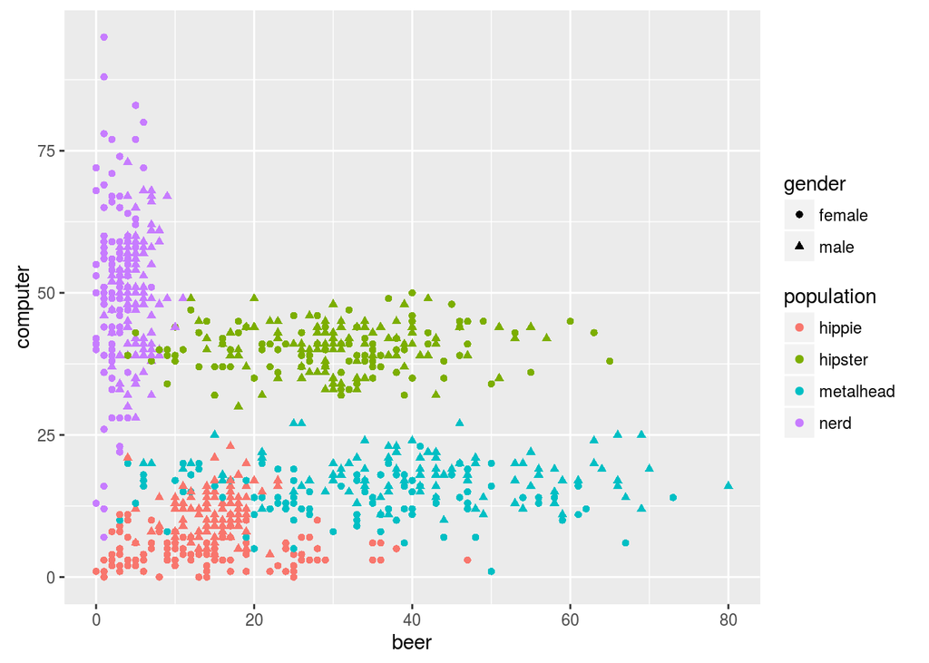

```r
c <- ggplot(stereotype_db, aes(beer, computer, color=population, shape=gender))
c+ geom_point()
```

### AB5-2

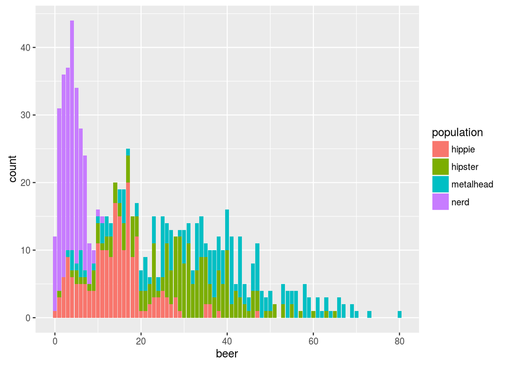

```r
d <- ggplot(stereotype_db, aes(beer, fill=population, shape=gender), colour="clarity")
d + geom_bar() + scale_color_hue(l=90, c=50)
```

### AB5-3

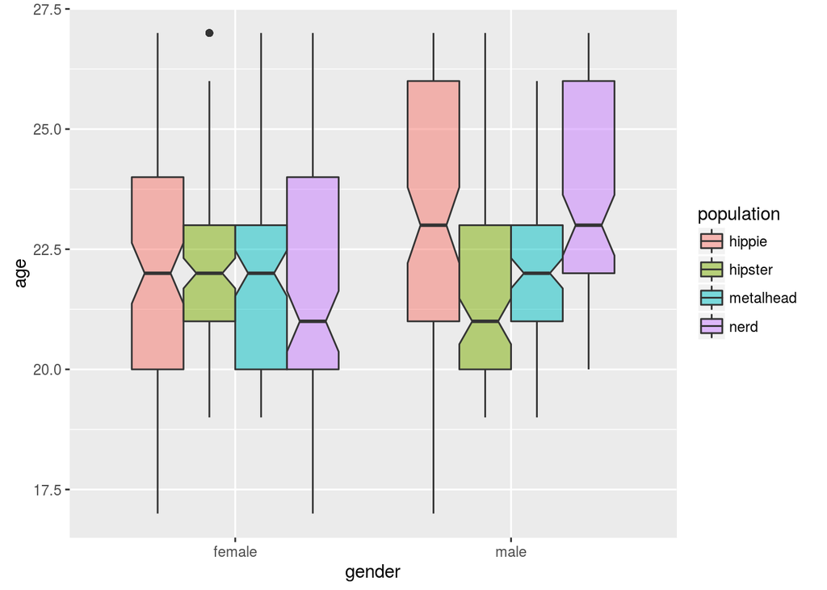

```r
f <- ggplot(stereotype_db, aes(gender, age))
f + geom_boxplot(aes(shape=population, fill=population), notch=TRUE, alpha=0.5)
```

## Visualization of the BLAST dataset

## Exercise 12

```r
fly.worm.sample <- sample(nrow(fly.worm), 10000)
fw.db <- fly.worm[fly.worm.sample, ]
summary(fw.db)
```

```
##        qid                sid            pct             len
##  C09D1.1g:  83   FBpp0304922:  33   Min.   :18.51   Min.   :  44
##  F15G9.4d:  82   FBpp0304925:  28   1st Qu.:26.24   1st Qu.: 203
##  F15G9.4b:  81   FBpp0304928:  27   Median :29.68   Median : 268
##  C09D1.1b:  77   FBpp0304929:  26   Mean   :31.80   Mean   : 341
##  F15G9.4a:  71   FBpp0290554:  25   3rd Qu.:34.58   3rd Qu.: 383
##  C09D1.1e:  70   FBpp0311242:  25   Max.   :98.68   Max.   :4008
##  (Other) :9536   (Other)    :9836
##       mis              gaps               qb                qe
##  Min.   :   1.0   Min.   :  0.000   Min.   :    1.0   Min.   :   50
##  1st Qu.: 121.0   1st Qu.:  4.000   1st Qu.:   39.0   1st Qu.:  286
##  Median : 161.0   Median :  7.000   Median :  133.0   Median :  432
##  Mean   : 202.4   Mean   :  9.822   Mean   :  767.8   Mean   : 1089
##  3rd Qu.: 226.0   3rd Qu.: 12.000   3rd Qu.:  448.0   3rd Qu.:  807
##  Max.   :2308.0   Max.   :124.000   Max.   :18225.0   Max.   :18528
##
##        sb                se                E                   S
##  Min.   :    1.0   Min.   :   64.0   Min.   :0.000e+00   Min.   :  57.4
##  1st Qu.:   48.0   1st Qu.:  318.0   1st Qu.:0.000e+00   1st Qu.:  79.0
##  Median :  218.5   Median :  522.0   Median :0.000e+00   Median :  98.2
##  Mean   :  693.9   Mean   : 1015.9   Mean   :2.206e-12   Mean   : 133.9
##  3rd Qu.:  570.0   3rd Qu.:  925.2   3rd Qu.:6.000e-15   3rd Qu.: 139.0
##  Max.   :20832.0   Max.   :21628.0   Max.   :1.000e-10   Max.   :2775.0
##
```

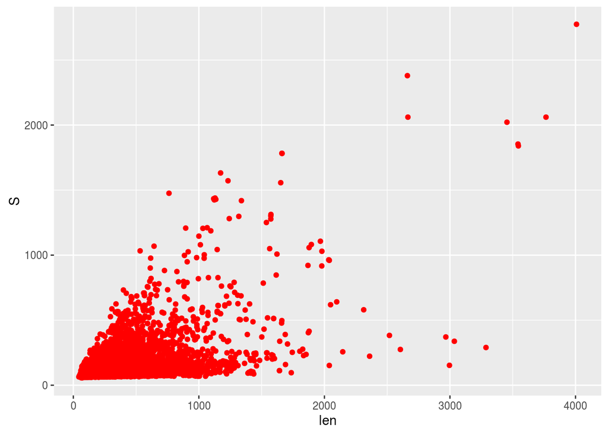

```r
score.length <- ggplot(fw.db, aes(len, S))
score.length + geom_point(colour="red")
```

## Exercise 13

Hypothesis: As the amount of gaps increase, the alignment length increases and as a result, the scores increase. So the bigger the gaps, the bigger the score.

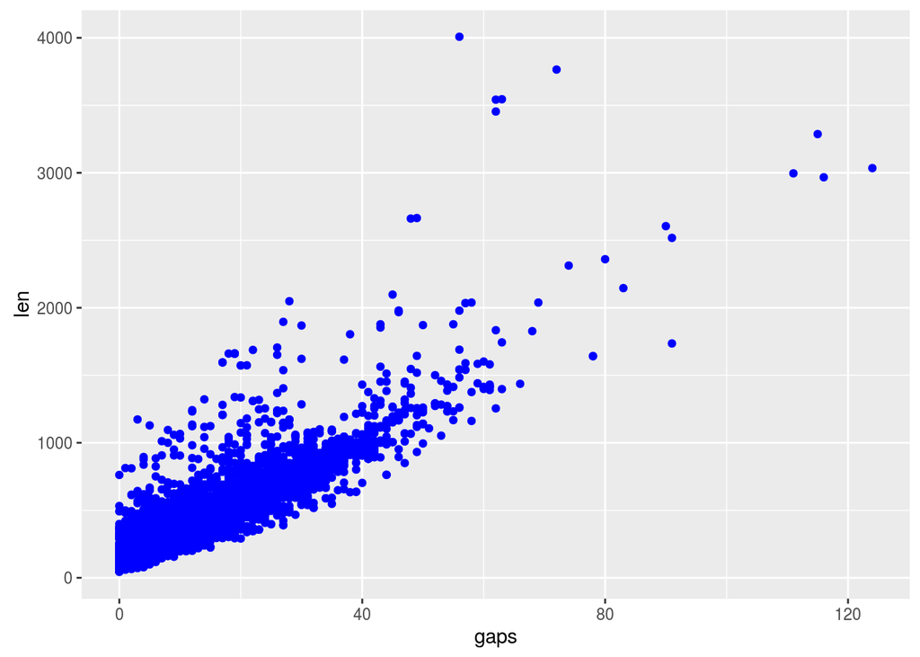

```r
length.gaps <- ggplot(fw.db, aes(x=gaps, y=len))
length.gaps + geom_point(colour = "blue")
```

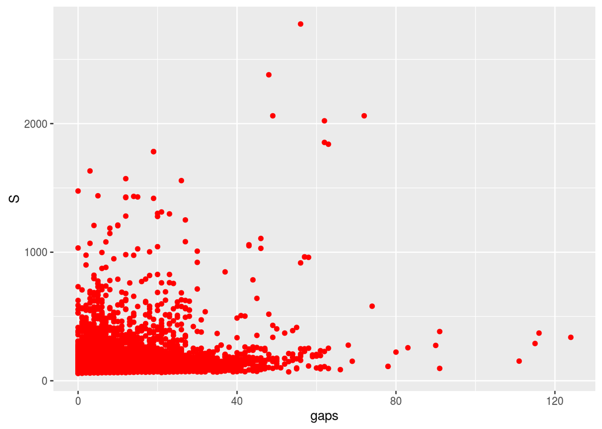

```r
score.gaps <- ggplot(fw.db, aes(gaps, S))
score.gaps + geom_point(colour = "red")
```